# plotor - Quick start

```r
library(plotor)
set.seed(123) # reproducibility
```

Short summary: minimal reproducible workflow showing model checks, a publication-ready odds ratio table and a forest plot.

## What this vignette covers

- Required input: a fitted glm object for binary outcome (family = binomial)
- Functions shown: `check_or()`, `table_or()` and `plot_or()`
- Output types demonstrated: tibble, gt table, ggplot2 plot.

## Minimal reproducible example

Create a small example dataset with clear factor levels and a binary outcome:

```r
rows <- 400
df <- data.frame(
  # the first factor level is the reference,
  # results in odds of 'Disease' vs 'Healthy'
  outcome = rbinom(n = rows, size = 1, prob = 0.25) |>
    factor(labels = c("Healthy", "Disease")),
  age = rnorm(n = rows, mean = 50, sd = 12),
  sex = sample(x = 0:1, size = rows, replace = TRUE) |>
    factor(labels = c("Female", "Male")),
  smoke = sample(x = 0:2, size = rows, replace = TRUE) |>
    factor(labels = c("Never", "Former", "Current"))
)
```

Fit a logistic regression model

```r
m <- glm(
  formula = outcome ~ age + sex + smoke,
  data = df,
  family = "binomial"
)
```

## Run diagnostics

Using `check_or()`

```r
check_or(m)
```

```
#>
#> ── Assumption checks ───────────────────────────────────────────────────────────
#>
#> ── Summary ──
#>
#> ✔ The outcome variable is binary
#> ✔ Predictor variables are not highly correlated with each other
#> ✔ The outcome is not separated by predictors
#> ✔ The sample size is large enough
#> ✔ Continuous variables either have a linear relationship with the log-odds of
#> the outcome or are absent
#> ✔ No observations unduly influence model estimates
#>
#> Your model was checked for logistic regression assumptions in the following
#> areas:
#>
#> Binary outcome:
#> The outcome variable was checked for containing precisely two levels.
#>
#> Multicollinearity:
#> The `vif()` function from the car package was used to check for highly
#> correlated predictor variables.
#>
#> Separation:
#> The `detectseparation()` function from the detectseparation package was used to
#> check for complete or quasi-complete separation in the data.
#>
#> Sample size:
#> A rule of thumb was applied, requiring at least 10 events per predictor
#> variable and at least 10 events per level of categorical variables to ensure
#> sufficient data for reliable estimates.
#>
#> Linearity:
#> A likelihood ratio test was conducted to assess improvements in model fit
#> compared to a model using Box-Tidwell power transformations on continuous
#> predictors. Any observed improvement likely indicates non-linear relationships
#> between the continuous predictors and the log-odds of the outcome.
#>
#> Influential observations:
#> A test to identify observations that could disproportionately influence model
#> statistics was applied. The test simultaneously examined three metrics: Cook's
#> distance (measuring overall observation impact), leverage (quantifying an
#> observation's distance from the data centre), and standardised residuals
#> (indicating how unusual an observation is relative to the model). To minimise
#> false positive, an observation was flagged only if it met at least two of these
#> diagnostic criteria.
#>
#> ✔ These tests found no issues with your model.
#>
```

- Runs quick checks (binary outcome, multicollinearity, separation, small-sample / rare-event, linearity, influential points)
- Behaviour: prints concise human-readable messages to the console
- Issues raised here may indicate you should undertake further work to validate your model and understand the causes of these alerts before relying on any results from your model.

## Create a publication-ready table

Using `table_or()`

```r
# two output formats shown: gt (rendered) and tibble (for programmatic use)
table_or(m, output = "gt") # formatted HTML table
```

outcome

Odds Ratio summary table with 95% Confidence Interval

|  | Characteristic<sup>1</sup> Level | Characteristic<sup>1</sup> N | Characteristic<sup>1</sup> n | Characteristic<sup>1</sup> Rate | Characteristic<sup>1</sup> Class | Odds Ratio (OR)<sup>2</sup> OR | Odds Ratio (OR)<sup>2</sup> SE | Odds Ratio (OR)<sup>2</sup> p | 95% Confidence Interval (CI)<sup>3</sup> Lower | 95% Confidence Interval (CI)<sup>3</sup> Upper | 95% Confidence Interval (CI)<sup>3</sup> Significance | OR Plot |  |
| --- | --- | --- | --- | --- | --- | --- | --- | --- | --- | --- | --- | --- | --- |
| age | age | 400 | 97 | 24.25% | numeric | 0.9897 | 0.009961 | 3.00 × 10<sup>−1</sup> | 0.9705 | 1.009 | Not significant |  |  |
| sex | Female | 206 | 53 | 25.73% | factor | — | — | — | — | — | Comparator |  |  |
|  | Male | 194 | 44 | 22.68% | factor | 0.8558 | 0.2350 | 5.07 × 10<sup>−1</sup> | 0.5385 | 1.355 | Not significant |  |  |
| smoke | Never | 137 | 34 | 24.82% | factor | — | — | — | — | — | Comparator |  |  |
|  | Former | 135 | 34 | 25.19% | factor | 1.028 | 0.2808 | 9.21 × 10<sup>−1</sup> | 0.5923 | 1.786 | Not significant |  |  |
|  | Current | 128 | 29 | 22.66% | factor | 0.9018 | 0.2903 | 7.22 × 10<sup>−1</sup> | 0.5085 | 1.592 | Not significant |  |  |

<sup>1</sup> **Characteristics** are the explanatory variables in the logistic regression analysis. For categorical variables the first characteristic is designated as a reference against which the others are compared. For numeric variables the results indicate a change per single unit increase. *Level* - the name or the description of the explanatory variable. *N* - the number of observations examined. *n* - the number of observations resulting in the outcome of interest. *Rate* - the proportion of observations resulting in the outcome of interest (n / N). *Class* - description of the data type.  
<sup>2</sup> **Odds Ratios** estimate the relative *odds* of an outcome with reference to the *Characteristic*. For categorical data the first level is the reference against which the odds of other levels are compared. Numerical characteristics indicate the change in *OR* for each additional increase of one unit in the variable. *OR* - The Odds Ratio point estimate - values below 1 indicate an inverse relationship whereas values above 1 indicate a positive relationship. Values shown to 4 significant figures. *SE* - Standard Error of the point estimate. Values shown to 4 significant figures. *p* - The p-value estimate based on the residual Chi-squared statistic.  
<sup>3</sup> **Confidence Interval** - the range of values likely to contain the *OR* in 95% of cases if this study were to be repeated multiple times. If the *CI* touches or crosses the value 1 then it is unlikely the *Characteristic* is significantly associated with the outcome. *Lower* & *Upper* - The range of values comprising the *CI*, shown to 4 significant figures. *Significance* - The statistical significance indicated by the *CI*, *Significant* where the *CI* does not touch or cross the value 1.

```r
table_or(m, output = "tibble") # programmatic output
```

```
#> # A tibble: 6 × 14
#>   label level    rows outcome outcome_rate class   estimate std.error statistic
#>   <fct> <fct>   <int>   <int>        <dbl> <chr>      <dbl>     <dbl>     <dbl>
#> 1 age   age       400      97        0.242 numeric    0.990   0.00996   -1.04
#> 2 sex   Female    206      53        0.257 factor    NA      NA         NA
#> 3 sex   Male      194      44        0.227 factor     0.856   0.235     -0.663
#> 4 smoke Never     137      34        0.248 factor    NA      NA         NA
#> 5 smoke Former    135      34        0.252 factor     1.03    0.281      0.0997
#> 6 smoke Current   128      29        0.227 factor     0.902   0.290     -0.356
#> # ℹ 5 more variables: p.value <dbl>, conf.low <dbl>, conf.high <dbl>,
#> #   significance <chr>, comparator <dbl>
```

#### Notes:

- table_or() exponentiates coefficients to present odds ratios
- Use the tibble output when you need to further transform or combine results programmatically

## Forest plot of odds ratios

Display the relationships in a forest plot using `plot_or()`

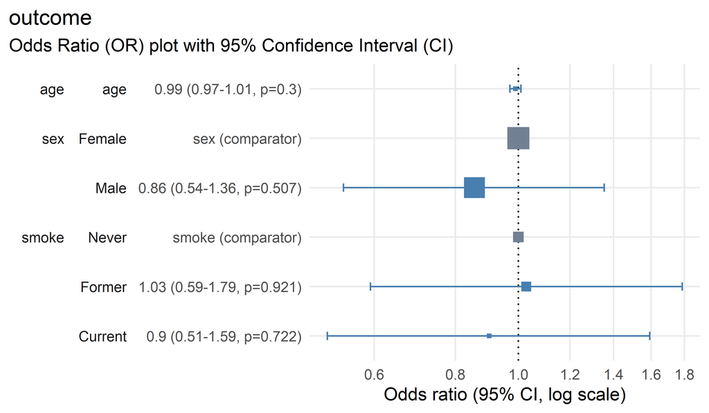

Forest plot shows point estimates and 95% confidence intervals; the vertical reference line at OR = 1 indicates no association

```r
plot_or(m)
```

## Quick interpretation

- `check_or()` flags potential model issues. Concerns raised here should be a prompt for further investigative work to understand the implications for your model’s validity.
- `table_or()` provides odds ratios, 95% confidence intervals and p-values in a publication-friendly layout. Prefer reporting confidence intervals alongside point estimates rather than p-values alone.
- `plot_or()` visualises effect sizes and uncertainty. Interpret odds ratios > 1 as increased odds; odds ratios < 1 as decreased odds. If the confidence interval crosses 1, there is no clear evidence of an association at the chosen confidence interval level (default 95%).

## See also

- `vignette("plot_or")` - detailed plotting options and themes
- `vignette("table_or")` - formatting, gt integration and export
- `vignette("check_or")` - diagnostics and case studies